# Fitting a power law to RBN data

This file processes the MergedList.csv file that is produced by the output_summary_combine.m script and contains upper and lower bounds for the number of attractors for the RBN networks in the ensemble. It also processes the MergedListTR_full.csv file that, in addition to the MergedList.csv data, contains lower bounds on the attractor counts calculated by finding minimal trap spaces using our iterative reduction methods.

We begin by importing various Python libraries we will need and setting plotting defaults. This notebook was tested by the authors using Python version 3.8.3 in Jupyter notebook version 6.0.3.

```python
import numpy as np
from scipy.optimize import least_squares
import matplotlib.pyplot as plt
from matplotlib.lines import Line2D
from matplotlib import ticker
import pandas as pd
import random as rd
import matplotlib
matplotlib.rcParams['figure.figsize'] = (15.0, 8.0)
font = {'family' : 'Arial',
        'weight' : 'normal',
        'size'   : 24}

matplotlib.rc('font', **font)
```

We generate the functions that will be used for the fitting. We are fitting the function $\langle A\rangle = a + bN^c $, and need to calculate its Jacobian with respect to the parameters $x=(a,b,c)$.

```python
def scaling_fit(x, u):
    ## <A> = a + bN^c , x=(a,b,c);<A>=y;N=u
    return x[0] + x[1] * (u ** x[2])

def fun(x, u, y):
    return scaling_fit(x, u) - y

def jac(x, u, y):
    ##  <A>_a = 1
    ##  <A>_b = N^c
    ##  <A>_c = b*ln(N)*N^c
    J = np.empty((u.size, x.size))
    powerlaw = u ** x[2]
    J[:, 0] = 1
    J[:, 1] = powerlaw
    J[:, 2] = x[1] * powerlaw * np.log(u)
    return J
```

We will fit the RBN data using nonlinear least-square fitting.

For each $N$, the attractor number $A$ is an independent random variable distributed according to $P(A;N)$. We generate an ensemble $\Omega(N)$ for each $N$, and estimate the average of $A$ for this ensemble: $\langle A\rangle_{\Omega(N)}$. The difference between $\langle A\rangle_{\Omega(N)}$ and the true $\langle A\rangle$ per $N$ should be an independent and normally distributed random variable as $\Omega(N) \rightarrow \infty$ (i.e. central limit theorem should hold for the estimate of $\langle A\rangle$ for each $N$).

# Loading the RBN data

We apply the following strategy for the networks with very high upper bounds and the ones for which we could not find bounds on the number of attractors:

- In some cases, the upper bound, $U$, is very large -- these are theoretical bounds obtained by considering an STG made of only 2-cycles and are extremely generous upper bounds. We consider $U$ to be unknown if it is greater than the lower bound, $L$, by more than 100.
- If $L$ is missing, set it to 1. This is a universally valid lower bound, as ever network must have at least one attractor.
- If $U$ is missing and $L$ is known, set $U$ to $1.25\times L$. This is equivalent to the assumption that, on average, each minimal trap space contains 1.25 attractors. Based on the experience of the authors, this is much higher than the likely (unknown) value.
- If $U$ is missing and $L$ is unknown, we first set $L=1$. To set $U$ for the $m_N$ intractible networks for each $N$, we select the $m_N$ largest known values of $U$ for networks of size $N$ (for which $U-L\leq 100$). We increase these values by $10\%$ and assign them to the intractible networks. This ensures that these networks have relative high upper bounds that are not overly sensitive to potential high-$U$ outliers.

For data in MergedListTR_full, we only use the lower bounds, as these networks were not analyzed with the goal of obtaining upper bounds.

```python
df_rbn_original=pd.read_csv("./MergedList.csv")
df_rbn_tr_original=pd.read_csv("./MergedListTR_full.csv")
df_rbn_tr = df_rbn_tr_original
df_rbn=df_rbn_original

ul_threshold=100
ul_multiplier=1.25
umax_multiplier=1.1

df_rbn["U-L"]=df_rbn["U"]-df_rbn["L"]
df_rbn["UL_NA"]=df_rbn["U"].isna() & df_rbn["L"].isna()
df_rbn["U-L_NA"]=df_rbn["U-L"]>=ul_threshold
df_rbn.loc[df_rbn["U-L"]>=ul_threshold,"U"]=np.NaN

# place bounds & fill in NaNs
for n in df_rbn["N"].unique():
    # if U is unknown (or unreasonably large), but L is known . . .
    df_rbn.loc[df_rbn["U-L_NA"] & ~df_rbn["UL_NA"] & (df_rbn["N"]==n),"U"]=ul_multiplier*df_rbn.loc[df_rbn["U-L_NA"] & ~df_rbn["UL_NA"] & (df_rbn["N"]==n),"L"]

    # if U and L are both unknown
    X=sorted(df_rbn[(df_rbn["N"]==n) & ~df_rbn["UL_NA"] & ~df_rbn["U-L_NA"]]["U"].tolist(),key=lambda x: -x)
    UN = [x*umax_multiplier for x in X]
    UL_NA_len=len(df_rbn.loc[df_rbn["UL_NA"] & (df_rbn["N"]==n),"U"])
    df_rbn.loc[df_rbn["UL_NA"] & (df_rbn["N"]==n),"U"]=UN[:UL_NA_len]
    df_rbn.loc[df_rbn["UL_NA"] & (df_rbn["N"]==n),"L"]=1
```

Having estimated missing values, we calculate the average per $N$ of $L$ and $U$ overall, and the average number of attractors for the networks with $U=L$ (i.e., those for which the number of attractors is exactly counted). We also compute the average lower bound per $N$ for the ensemble that includes the networks analyzed by trap space methods alone.

```python
N_vals=list(df_rbn["N"].unique())
A_mean=[];UA_mean=[];LA_mean=[]
A_sem=[];UA_sem=[];LA_sem=[]
A_count=[];UA_count=[];LA_count=[]

TR_N_vals=list(df_rbn_tr["N"].unique())
TR_sem=[];TR_mean=[];TR_count=[]

for n in df_rbn["N"].unique():
    df_n=df_rbn[df_rbn["N"]==n]

    UA_mean.append(df_n["U"].mean())
    UA_sem.append(df_n["U"].sem())
    UA_count.append( df_n["U"].count())

    LA_mean.append(df_n["L"].mean())
    LA_sem.append(df_n["L"].sem())
    LA_count.append(df_n["L"].count())

    df_n=df_n.loc[df_n["U-L"]==0]
    A_mean.append(df_n["L"].mean())
    A_sem.append(df_n["L"].sem())
    A_count.append(df_n["L"].count())

for n in df_rbn_tr["N"].unique():
    df_n_tr=df_rbn_tr[df_rbn_tr["N"]==n]

    TR_mean.append(df_n_tr["L"].mean())
    TR_sem.append(df_n_tr["L"].sem())
    TR_count.append( df_n_tr["L"].count())
```

As an overview of the averaged values, we plot the results.

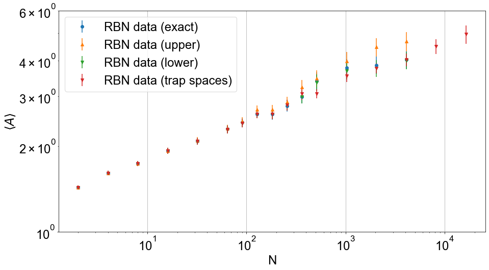

```python
fig,ax = plt.subplots(ncols=1,nrows=1)
ax.set_facecolor('white')
fig.set_facecolor('white')
plt.errorbar(N_vals, A_mean, yerr=A_sem,fmt='o',label='RBN data (exact)')
plt.errorbar(N_vals, UA_mean, yerr=UA_sem,fmt='^', label='RBN data (upper)')
plt.errorbar(N_vals, LA_mean, yerr=LA_sem,fmt='v', label='RBN data (lower)')
plt.errorbar(TR_N_vals, TR_mean, yerr=TR_sem,fmt='v',label='RBN data (trap spaces)')
plt.loglog()
plt.grid()
plt.xlabel("N")
plt.ylabel(r"$\langle A\rangle$")
plt.legend()
plt.ylim(1,6)
plt.show()
```

We next attempt to fit a power law to each of these data sets. As our initial guess we use $\langle A\rangle=a + bN^c$ with c=0.5 (the original powerlaw from Kauffman) and $a$ and $b$ such that the values at the extremes ($\langle A\rangle_{N=2}$ and $\langle A\rangle_{N=4096}$) are exactly fit. If the parameters for the resulting initial fit fall outside reasonable bounds, we fall back to $\langle A\rangle=N^{1/2}$. We then use SciPy to perform a local least-squares optimization with the chosen values of $a$, $b$, and $c$ as the initial point.

```python
def fit_to_data(u_vals,y_vals,verbose=1,bounds = ([-10,0,0],[10,10,2])):
    u = np.array(u_vals)
    y = np.array(y_vals)

    a_num=np.sqrt(u[0])*y[-1]-np.sqrt(u[-1])*y[0]
    b_num=y[0]-y[-1]
    ab_dem=np.sqrt(u[0])-np.sqrt(u[-1])
    a=a_num/ab_dem
    b=b_num/ab_dem

    x0 = np.array([a,b,0.5])

    try:
        res = least_squares(fun, x0, jac=jac, bounds=bounds, args=(u, y), verbose=verbose)
    except ValueError:
        x0 = np.array([0,1,0.5])
        res = least_squares(fun, x0, jac=jac, bounds=bounds, args=(u, y), verbose=verbose)

    exponent="{0:.3g}".format(res.x[2])
    return(res,exponent)

u = np.array(N_vals)
y = np.array(A_mean)
y_error=np.array(A_sem)
res_exact,exponent_exact=fit_to_data(u,y)

u = np.array(N_vals)
y = np.array(UA_mean)
y_error=np.array(UA_sem)
res_upper,exponent_upper=fit_to_data(u,y)

u = np.array(N_vals)
y = np.array(LA_mean)
y_error=np.array(LA_sem)
res_lower,exponent_lower=fit_to_data(u,y)

u = np.array(TR_N_vals)
y = np.array(TR_mean)
y_error=np.array(TR_sem)
res_tr,exponent_tr=fit_to_data(u,y)
```

```
`ftol` termination condition is satisfied.
Function evaluations 21, initial cost 3.0573e+00, final cost 1.0773e-01, first-order optimality 1.74e-07.
`ftol` termination condition is satisfied.
Function evaluations 13, initial cost 2.7943e+00, final cost 7.9086e-02, first-order optimality 9.57e-06.
`ftol` termination condition is satisfied.
Function evaluations 22, initial cost 2.9190e+00, final cost 7.8470e-02, first-order optimality 2.81e-06.
`ftol` termination condition is satisfied.
Function evaluations 28, initial cost 5.1695e+01, final cost 2.5061e-02, first-order optimality 4.10e-08.
```

```python
print("Exponent (exact):",exponent_exact,", cost function (1/2 sum of squares of residuals):","{0:.3g}".format(res_exact.cost))
print("Exponent (upper):",exponent_upper,", cost function (1/2 sum of squares of residuals):","{0:.3g}".format(res_upper.cost))
print("Exponent (lower):",exponent_lower,", cost function (1/2 sum of squares of residuals):","{0:.3g}".format(res_lower.cost))
print("Exponent (trap spaces):",exponent_tr,", cost function (1/2 sum of squares of residuals):","{0:.3g}".format(res_tr.cost))
print("All parameters (exact) (a,b,c):",res_exact.x)
print("All parameters (upper) (a,b,c):",res_upper.x)
print("All parameterst (lower) (a,b,c):",res_lower.x)
print("All parameterst (trap space) (a,b,c):",res_tr.x)
```

```
Exponent (exact): 0.125 , cost function (1/2 sum of squares of residuals): 0.108
Exponent (upper): 0.199 , cost function (1/2 sum of squares of residuals): 0.0791
Exponent (lower): 0.117 , cost function (1/2 sum of squares of residuals): 0.0785
Exponent (trap spaces): 0.13 , cost function (1/2 sum of squares of residuals): 0.0251
All parameters (exact) (a,b,c): [-0.37564371  1.62930692  0.1245804 ]
All parameters (upper) (a,b,c): [0.44083486 0.84786459 0.19874629]
All parameterst (lower) (a,b,c): [-0.49952939  1.75496614  0.11695537]
All parameterst (trap space) (a,b,c): [-0.15748774  1.45056171  0.12965596]
```

The cost function (1/2 sum of squares of residuals) is low for all fits. We now plot the best-fit curve to the data

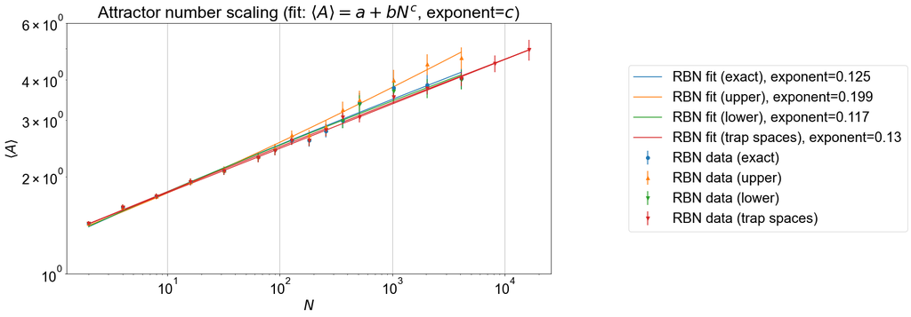

```python
fig,ax = plt.subplots(ncols=1,nrows=1)
ax.set_facecolor('white')
fig.set_facecolor('white')
u = np.array(N_vals)
y = np.array(A_mean)
y_error=np.array(A_sem)
exponent=exponent_exact
res=res_exact
plt.errorbar(u, y, yerr=y_error,fmt='o',label='RBN data (exact)',color="C0")
plt.plot(u, scaling_fit(res.x, u), '-', label='RBN fit (exact), exponent='+str(exponent),color="C0")

u = np.array(N_vals)
y = np.array(UA_mean)
y_error=np.array(UA_sem)
exponent=exponent_upper
res=res_upper
plt.errorbar(u, y, yerr=y_error,fmt='^',label='RBN data (upper)',color="C1")
plt.plot(u, scaling_fit(res.x, u), '-', label='RBN fit (upper), exponent='+str(exponent),color="C1")

u = np.array(N_vals)
y = np.array(LA_mean)
y_error=np.array(LA_sem)
exponent=exponent_lower
res=res_lower
plt.errorbar(u, y, yerr=y_error,fmt='v',label='RBN data (lower)',color="C2")
plt.plot(u, scaling_fit(res.x, u), '-', label='RBN fit (lower), exponent='+str(exponent),color="C2")

u = np.array(TR_N_vals)
y = np.array(TR_mean)
y_error=np.array(TR_sem)
exponent=exponent_tr
res=res_tr
plt.errorbar(u, y, yerr=y_error,fmt='v',label='RBN data (trap spaces)',color="C3")
plt.plot(u, scaling_fit(res.x, u), '-', label='RBN fit (trap spaces), exponent='+str(exponent),color="C3")

plt.loglog()
plt.grid()
plt.title("Attractor number scaling (fit: "+r"$\langle A\rangle=a+bN^c$"+", exponent=$c$)")
plt.xlabel("$N$")
plt.ylabel(r"$\langle A\rangle$")
plt.legend()
plt.legend(loc='center right',bbox_to_anchor=(1.75, 0.5))
plt.ylim(1,6)
plt.show()
```

Because the trap space data contains the lower bounds data as a subset, and does itself provide lower bounds for all networks in the ensemble, we present it as a more complete version of the lower bound data, as plotted below. The result is figure 7 of the accompanying paper.

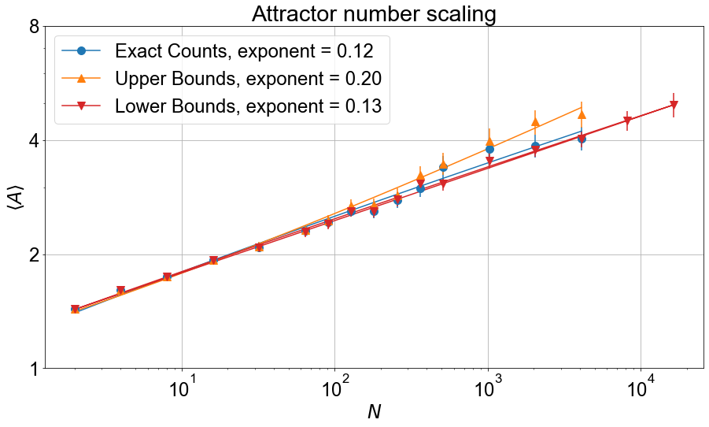

```python
fig,ax = plt.subplots(ncols=1,nrows=1)
ax.set_facecolor('white')
fig.set_facecolor('white')
u = np.array(N_vals)
y = np.array(A_mean)
y_error=np.array(A_sem)
exponent=exponent_exact
res=res_exact
plt.errorbar(u, y, yerr=y_error,fmt='o',label='RBN data (exact)',color="C0",markersize=10)
plt.plot(u, scaling_fit(res.x, u), '-', label='RBN fit (exact), c='+str(exponent),color="C0")

u = np.array(N_vals)
y = np.array(UA_mean)
y_error=np.array(UA_sem)
exponent=exponent_upper
res=res_upper
plt.errorbar(u, y, yerr=y_error,fmt='^',label='RBN data (upper)',color="C1",markersize=10)
plt.plot(u, scaling_fit(res.x, u), '-', label='RBN fit (upper), c='+str(exponent),color="C1")

# plotting lower bounds + trap spaces together
u = np.array(TR_N_vals)
y = np.array(TR_mean)
y_error=np.array(TR_sem)
exponent=exponent_tr
res=res_tr
plt.errorbar(u, y, yerr=y_error,fmt='v',label='RBN data (lower)',color="C3",markersize=10)
plt.plot(u, scaling_fit(res.x, u), '-', label='RBN fit (lower), c='+str(exponent),color="C3")

def round2(s):
    return "{0:.2f}".format(round(float(s),2))

legend_labels = [Line2D([0], [0], color='C0', marker='o', markersize=10, label='Exact Counts, exponent = '+round2(exponent_exact)),
                 Line2D([0], [0], color='C1', marker='^', markersize=10, label='Upper Bounds, exponent = '+round2(exponent_upper)),
                 Line2D([0], [0], color='C3', marker='v', markersize=10, label='Lower Bounds, exponent = '+round2(exponent_tr))]

#fs = 16
plt.loglog()
ax.set_yticks([1,2,4,8])
ax.set_yticklabels(['1','2','4','8'])
ax.yaxis.set_minor_formatter(ticker.NullFormatter())
ax.get_yaxis().set_major_formatter(ticker.ScalarFormatter())
ax.get_yaxis().get_major_formatter().labelOnlyBase = False
plt.grid()
plt.title(r"Attractor number scaling")
plt.xlabel(r"$N$")
plt.ylabel(r"$\langle A\rangle$")
plt.legend(handles=legend_labels,loc='upper left')
plt.ylim(1,8)
plt.show()
```

# Confidence interval of exponents through boostrapping

To find the confidence intervals of the fits, we will use a boostrap approach.

- For each $N$, a boostrap sample is a sample with replacement from $\Omega(N)$ of size $\left|\Omega(N)\right|$.
- For each boostrap sample, we use nonlinear least squares to fit the curve and get the best-fit exponent.
- We generate $n_{boostrap}=10000$ bootstrap samples and compute the best-fit exponent for each. From these fits, we obtain the 95% confidence interval of the exponent from the best-fit exponent distribution ($2.5\%$ and $97.5\%$ quantiles).
- We will see that the bootstrap distributions are approximately normal, and so we will also compute their standard deviations.

We begin by defining the relevant bootstrap functions.

```python
def bootstrap_generate(df_data,n_bootstrap,seed):
    rd.seed(seed)
    N_vals=list(df_data["N"].unique())
    A_means={};UA_means={};LA_means={}

    for n in df_data["N"].unique():
        df_n=df_data[df_data["N"]==n]
        UA_mean=[];LA_mean=[]
        for n_rep in range(n_bootstrap):
            resample=rd.choices(df_n["U"].tolist(),k=df_n["U"].count())
            UA_mean.append(np.mean(resample))

            resample=rd.choices(df_n["L"].tolist(),k=df_n["L"].count())
            LA_mean.append(np.mean(resample))

        df_n=df_n.loc[df_n["U-L"]==0]
        A_mean=[];
        for n_rep in range(n_bootstrap):
            resample=rd.choices(df_n["U"].tolist(),k=df_n["U"].count())
            A_mean.append(np.mean(resample))

        A_means[n]=A_mean
        UA_means[n]=UA_mean
        LA_means[n]=LA_mean
    return(A_means,UA_means,LA_means)

def bootstrap_generate_tr(df_data,n_bootstrap,seed):
    rd.seed(seed)
    N_vals=list(df_data["N"].unique())
    LA_means={}

    for n in df_data["N"].unique():
        df_n=df_data[df_data["N"]==n]
        LA_mean=[]
        for n_rep in range(n_bootstrap):
            resample=rd.choices(df_n["L"].tolist(),k=df_n["L"].count())
            LA_mean.append(np.mean(resample))

        LA_means[n]=LA_mean
    return LA_means

def bootstrap_fit(bootstrap_data,n_bootstrap):
    u = np.array(list(bootstrap_data.keys()))
    fits=[]
    exponents=[]
    sk = 0
    for n_rep in range(n_bootstrap):
        y = np.array([bootstrap_data[n][n_rep] for n in u])
        res,exponent=fit_to_data(u,y,verbose=0)
        fits.append(res)
        exponents.append(res.x[2])

    return(fits,exponents)
```

Next, we generate the bootstrap ensembles.

```python
n_bootstrap=10000
seed=1000
A_means,UA_means,LA_means=bootstrap_generate(df_rbn,n_bootstrap,seed)
TR_means=bootstrap_generate_tr(df_rbn_tr,n_bootstrap,seed)
```

Now, we fit a power law to each bootstrap ensemble.

```python
fits_TR,exponents_TR=bootstrap_fit(TR_means,n_bootstrap)
fits_A,exponents_A=bootstrap_fit(A_means,n_bootstrap)
fits_UA,exponents_UA=bootstrap_fit(UA_means,n_bootstrap)
```

Finally, we display and plot the confidence intervals and standard deviations.

```python
from numpy import std, mean
qint = [0+0.05/2,1-0.05/2]
exponents_A_95conf=list(np.quantile(exponents_A, qint))
exponents_UA_95conf=list(np.quantile(exponents_UA, qint))
exponents_TR_95conf=list(np.quantile(exponents_TR, qint))

print("Exponent (exact) 95% confidence interval",["{0:.3g}".format(x) for x in exponents_A_95conf])
print("Exponent (upper) 95% confidence interval",["{0:.3g}".format(x) for x in exponents_UA_95conf])
print("Exponent (trap space) 95% confidence interval",["{0:.3g}".format(x) for x in exponents_TR_95conf])

print("Mean (exact)","{0:.3g}".format(mean(exponents_A)))
print("Mean (upper)","{0:.3g}".format(mean(exponents_UA)))
print("Mean (lower)","{0:.3g}".format(mean(exponents_TR)))

print("Standard deviation (exact)","{0:.3g}".format(std(exponents_A)))
print("Standard deviation (upper)","{0:.3g}".format(std(exponents_UA)))
print("Standard deviation (lower)","{0:.3g}".format(std(exponents_TR)))
```

```
Exponent (exact) 95% confidence interval ['0.0377', '0.223']
Exponent (upper) 95% confidence interval ['0.107', '0.303']
Exponent (trap space) 95% confidence interval ['0.061', '0.211']
Mean (exact) 0.125
Mean (upper) 0.199
Mean (lower) 0.13
Standard deviation (exact) 0.0467
Standard deviation (upper) 0.0503
Standard deviation (lower) 0.0383
```

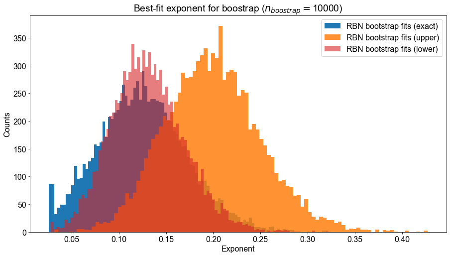

```python
font = {'family' : 'Arial',
        'weight' : 'normal',
        'size'   : 16}

matplotlib.rc('font', **font)

fig,ax = plt.subplots(ncols=1,nrows=1)
ax.set_facecolor('white')
fig.set_facecolor('white')
plt.hist(exponents_A,100,color="C0",alpha=1,label='RBN bootstrap fits (exact)')
plt.hist(exponents_UA,100,color="C1",alpha=0.85,label='RBN bootstrap fits (upper)')
plt.hist(exponents_TR,100,color="C3",alpha=0.6,label='RBN bootstrap fits (lower)')

plt.legend()
plt.title("Best-fit exponent for boostrap ($n_{boostrap}=$"+str(n_bootstrap)+")")
plt.xlabel("Exponent")
plt.ylabel("Counts")
plt.show()
```